# Ruffley & Lutz et al. — statistics computed for the NEE revision

Flowering time × WUE (δ¹³C): correlations, slopes, covariances

2026-08-12

Everything below is recomputed from the deposited data. Written to answer Reviewer 2 comment 1 (“no p-value or r² values are listed”) and the related Reviewer 1 points on Fig. 3B/3C.

# Source data

```r
SUB  <- "~/projects/natvar/NatEcoEvo_SubmissionNovember"
DAT  <- file.path(SUB, "Athaliana_Natural_Selection_Conflict/data")
CHAM <- "~/projects/natvar/Ruffley_Lutz_et_al_joint_MS/Data_code_Ruffley_Lutz_et_al"

src <- data.frame(
  file = c("deltaC_extended_group_rep3.csv",
           "deltaC_extended_group_rep3_pval.csv",
           "lines_info_annot.csv",
           "atlas1001_phenotypes_matrix_MR.csv",
           "imputed_wt&mut_dc13.csv",
           "atlas1001_phenotype_matrix_imputed_withID.csv"),
  where = c(CHAM, CHAM, CHAM, DAT, DAT, DAT),
  what = c("Uli's δ¹³C experiment: 49 line means (29 flc-edited, 19 wild-type progenitors, Col-0), 3 reps each. Fig. 3B source.",
           "The 19 edited lines that have a paired wild-type progenitor, with per-line p-values vs that progenitor.",
           "Metadata for 112 edited lines: progenitor accession, FT16 from 1001G, wild-type flowering time and FLC qRT.",
           "1001 Genomes phenotype matrix, MEASURED values (Delta_13C, FT10, FT16).",
           "Imputed δ¹³C for 306 accessions, separate wild-type and flc-mutant predictions.",
           "1001 Genomes phenotype matrix, IMPUTED values for all 1135 accessions (Delta_13C, FT16)."))
knitr::kable(src[, c("file", "what")])
```

| file | what |
| --- | --- |
| deltaC_extended_group_rep3.csv | Uli’s δ¹³C experiment: 49 line means (29 flc-edited, 19 wild-type progenitors, Col-0), 3 reps each. Fig. 3B source. |
| deltaC_extended_group_rep3_pval.csv | The 19 edited lines that have a paired wild-type progenitor, with per-line p-values vs that progenitor. |
| lines_info_annot.csv | Metadata for 112 edited lines: progenitor accession, FT16 from 1001G, wild-type flowering time and FLC qRT. |
| atlas1001_phenotypes_matrix_MR.csv | 1001 Genomes phenotype matrix, MEASURED values (Delta_13C, FT10, FT16). |
| imputed_wt&mut_dc13.csv | Imputed δ¹³C for 306 accessions, separate wild-type and flc-mutant predictions. |
| atlas1001_phenotype_matrix_imputed_withID.csv | 1001 Genomes phenotype matrix, IMPUTED values for all 1135 accessions (Delta_13C, FT16). |

```r
d  <- read.csv(file.path(CHAM, "deltaC_extended_group_rep3.csv"))
pr <- read.csv(file.path(CHAM, "deltaC_extended_group_rep3_pval.csv"))
at <- read.csv(file.path(DAT,  "atlas1001_phenotypes_matrix_MR.csv"))
im <- read.csv(file.path(DAT,  "imputed_wt&mut_dc13.csv"))

# groups. dag_mean = days to flowering, 21 C chamber; deltaC_mean_mean = measured d13C
E   <- subset(d, label == "mut")                 # 29 edited lines
W   <- subset(d, label == "wt")                  # 19 wild-type progenitors
WC  <- subset(d, label %in% c("wt", "col"))      # + Col-0  (n = 20; this is the Fig 3B green fit)
at16 <- at[!is.na(at$FT16) & !is.na(at$Delta_13C), ]
at10 <- at[!is.na(at$FT10) & !is.na(at$Delta_13C), ]
c(edited = nrow(E), progenitors = nrow(W), progenitors_col0 = nrow(WC),
  atlas_FT16 = nrow(at16), atlas_FT10 = nrow(at10))
```

```
##           edited      progenitors progenitors_col0       atlas_FT16
##               29               19               20              248
##       atlas_FT10
##              261
```

Each of the 29 edited lines comes from a **distinct** accession (no pseudo-replication), and all 29 have δ¹³C measured in triplicate. The 19 are the subset with a paired progenitor — *not* a measured-vs-imputed distinction.

```r
firstnum <- function(v) as.numeric(sapply(v, function(x) {
  m <- regmatches(x, regexpr("[0-9]+", x)); if (length(m)) m else NA }))
c(edited_lines = nrow(E), unique_accessions = length(unique(firstnum(E$line))),
  all_measured_3reps = sum(E$deltaC_mean_count == 3),
  paired_subset_of_29 = all(pr$line %in% E$line))
```

```
##        edited_lines   unique_accessions  all_measured_3reps paired_subset_of_29
##                  29                  29                  29                   1
```

# Core statistics

```r
stat <- function(x, y, label) {
  ok <- !is.na(x) & !is.na(y); x <- x[ok]; y <- y[ok]
  ct <- cor.test(x, y); f <- lm(y ~ x)
  data.frame(set = label, n = length(x),
             r = round(unname(ct$estimate), 3),
             p = signif(ct$p.value, 3),
             slope = round(unname(coef(f)[2]), 2),
             slope_SE = round(summary(f)$coef[2, 2], 2),
             cov = round(cov(x, y), 3),
             sd_d13C = round(sd(x), 3),
             sd_FT = round(sd(y), 2))
}

# imputed δ13C merge, used again in later sections
d$acc <- firstnum(d$line); d$acc[d$label == "col"] <- 6909
m   <- merge(d, im, by.x = "acc", by.y = "id", all.x = TRUE)
E28 <- subset(m, label == "mut" & !is.na(flc_mut_dc13))            # CS77069 absent
W19 <- subset(m, label %in% c("wt", "col") & !is.na(wt_dc13))      # Col-0 absent
ai  <- read.csv(file.path(DAT, "atlas1001_phenotype_matrix_imputed_withID.csv"))

tab <- rbind(
  stat(pr$deltaC_mean_mean, pr$dag_mean,   "19 edited (paired w/ progenitor)"),
  stat(E$deltaC_mean_mean,  E$dag_mean,    "29 edited (all)"),
  stat(W$deltaC_mean_mean,  W$dag_mean,    "19 progenitors"),
  stat(WC$deltaC_mean_mean, WC$dag_mean,   "20 progenitors + Col-0"),
  stat(at16$Delta_13C,      at16$FT16,     "248 natural accessions (FT16)"),
  stat(at10$Delta_13C,      at10$FT10,     "261 natural accessions (FT10)"),
  stat(E28$flc_mut_dc13,    E28$dag_mean,  "28 edited (imputed d13C)"),
  stat(W19$wt_dc13,         W19$dag_mean,  "19 progenitors (imputed d13C)"),
  stat(ai$Delta_13C,        ai$FT16,       "1135 natural accessions (imputed, FT16)"))
knitr::kable(tab, row.names = FALSE)
```

| set | n | r | p | slope | slope_SE | cov | sd_d13C | sd_FT |
| --- | --- | --- | --- | --- | --- | --- | --- | --- |
| 19 edited (paired w/ progenitor) | 19 | 0.499 | 0.0298 | 6.15 | 2.59 | 1.331 | 0.465 | 5.74 |
| 29 edited (all) | 29 | 0.376 | 0.0447 | 4.58 | 2.18 | 0.902 | 0.444 | 5.41 |
| 19 progenitors | 19 | -0.066 | 0.7890 | -5.07 | 18.66 | -0.722 | 0.377 | 29.09 |
| 20 progenitors + Col-0 | 20 | 0.144 | 0.5450 | 10.44 | 16.94 | 1.876 | 0.424 | 30.79 |
| 248 natural accessions (FT16) | 248 | 0.381 | 0.0000 | 8.63 | 1.33 | 12.262 | 1.192 | 26.97 |
| 261 natural accessions (FT10) | 261 | 0.431 | 0.0000 | 6.80 | 0.88 | 9.620 | 1.190 | 18.77 |
| 28 edited (imputed d13C) | 28 | 0.376 | 0.0489 | 4.58 | 2.22 | 0.935 | 0.452 | 5.51 |
| 19 progenitors (imputed d13C) | 19 | 0.138 | 0.5740 | 2.56 | 4.46 | 6.288 | 1.568 | 29.09 |
| 1135 natural accessions (imputed, FT16) | 1135 | 0.586 | 0.0000 | 19.90 | 0.82 | 10.466 | 0.725 | 24.61 |

Flowering time is days-to-flowering at 21 °C for the chamber sets and FT10/FT16 for the natural accessions, so slopes are comparable in kind but not identical quantities.

`20 progenitors + Col-0` reproduces the `β = 10.44 ± 16.9` reported in the manuscript, confirming the Fig. 3B wild-type line includes Col-0.

The last three rows are the imputed sets of Supplement §VIII.2: 28 edited (CS77069 is absent from the imputed panel), 19 progenitors (Col-0 is absent), and the full 1135- accession 1001 Genomes panel with imputed δ¹³C × imputed FT16. Flowering time in the two chamber rows is still the measured value — only δ¹³C is imputed there.

# Visualisation

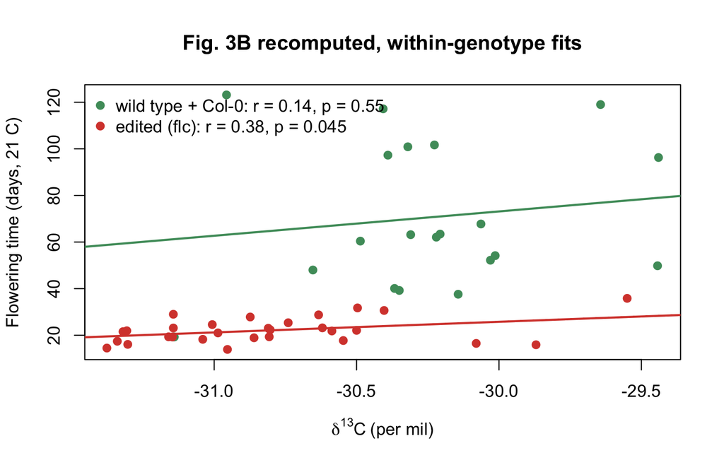

```r
plot(WC$deltaC_mean_mean, WC$dag_mean, pch = 19, col = "#4E9A6A",
     xlim = range(d$deltaC_mean_mean), ylim = range(d$dag_mean),
     xlab = expression(delta^13*C~"(per mil)"), ylab = "Flowering time (days, 21 C)",
     main = "Fig. 3B recomputed, within-genotype fits")
points(E$deltaC_mean_mean, E$dag_mean, pch = 19, col = "#D7473A")
abline(lm(dag_mean ~ deltaC_mean_mean, data = WC), col = "#4E9A6A", lwd = 2)
abline(lm(dag_mean ~ deltaC_mean_mean, data = E),  col = "#D7473A", lwd = 2)
legend("topleft", bty = "n", pch = 19, col = c("#4E9A6A", "#D7473A"),
       legend = c(sprintf("wild type + Col-0: r = %.2f, p = %.2f",
                          cor(WC$deltaC_mean_mean, WC$dag_mean),
                          cor.test(WC$deltaC_mean_mean, WC$dag_mean)$p.value),
                  sprintf("edited (flc): r = %.2f, p = %.3f",
                          cor(E$deltaC_mean_mean, E$dag_mean),
                          cor.test(E$deltaC_mean_mean, E$dag_mean)$p.value)))
```

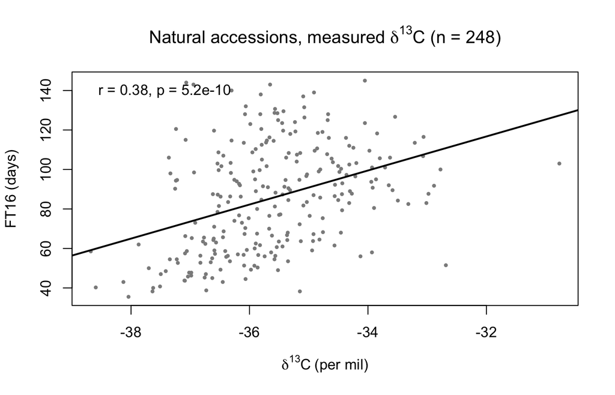

```r
plot(at16$Delta_13C, at16$FT16, pch = 19, cex = .45, col = "grey55",
     xlab = expression(delta^13*C~"(per mil)"), ylab = "FT16 (days)",
     main = expression("Natural accessions, measured "*delta^13*C*" (n = 248)"))
abline(lm(FT16 ~ Delta_13C, data = at16), col = "black", lwd = 2)
legend("topleft", bty = "n",
       legend = sprintf("r = %.2f, p = %.1e", cor(at16$Delta_13C, at16$FT16),
                        cor.test(at16$Delta_13C, at16$FT16)$p.value))
```

The natural δ¹³C range (−38.7 to −30.8‰) barely overlaps the chamber range (−31.4 to −29.4‰); the two cannot be overlaid on a raw axis.

# Formal tests

```r
fz <- function(r1, r2, n1, n2) {
  z <- (atanh(r1) - atanh(r2)) / sqrt(1/(n1 - 3) + 1/(n2 - 3))
  c(z = round(z, 3), p = round(2 * (1 - pnorm(abs(z))), 4)) }

rbind(
  `edited vs natural (FT16)`  = fz(cor(E$deltaC_mean_mean, E$dag_mean),
                                   cor(at16$Delta_13C, at16$FT16), nrow(E), nrow(at16)),
  `edited vs natural (FT10)`  = fz(cor(E$deltaC_mean_mean, E$dag_mean),
                                   cor(at10$Delta_13C, at10$FT10), nrow(E), nrow(at10)),
  `edited vs progenitors+Col0`= fz(cor(E$deltaC_mean_mean, E$dag_mean),
                                   cor(WC$deltaC_mean_mean, WC$dag_mean), nrow(E), nrow(WC)))
```

```
##                                 z      p
## edited vs natural (FT16)   -0.033 0.9736
## edited vs natural (FT10)   -0.321 0.7482
## edited vs progenitors+Col0  0.802 0.4227
```

```r
b <- rbind(data.frame(x = E$deltaC_mean_mean,  y = E$dag_mean,  g = "edited"),
           data.frame(x = WC$deltaC_mean_mean, y = WC$dag_mean, g = "progenitor"))
round(summary(lm(y ~ x * g, data = b))$coef, 4)   # interaction = slope difference
```

```
##               Estimate Std. Error t value Pr(>|t|)
## (Intercept)   163.1935   264.8553  0.6162   0.5409
## x               4.5799     8.5963  0.5328   0.5968
## gprogenitor   223.1604   423.5029  0.5269   0.6008
## x:gprogenitor   5.8605    13.9030  0.4215   0.6754
```

```r
cc <- function(s) cov(s$deltaC_mean_mean, s$dag_mean)
obs <- cc(E) - cc(WC)
boot <- replicate(20000, cc(E[sample(nrow(E), replace = TRUE), ]) -
                          cc(WC[sample(nrow(WC), replace = TRUE), ]))
c(observed_difference = round(obs, 3),
  CI_lower = round(quantile(boot, .025), 3), CI_upper = round(quantile(boot, .975), 3))
```

```
## observed_difference       CI_lower.2.5%      CI_upper.97.5%
##              -0.974              -8.509               6.281
```

**The variance test is the robust result.** Editing collapses flowering-time variance ~32-fold while leaving δ¹³C variance untouched.

```r
rbind(d13C = c(progenitors = var(WC$deltaC_mean_mean), edited = var(E$deltaC_mean_mean)),
      FT   = c(var(WC$dag_mean), var(E$dag_mean)))
```

```
##      progenitors     edited
## d13C   0.1796541  0.1969672
## FT   947.7433865 29.2977866
```

```r
var.test(WC$dag_mean, E$dag_mean)
```

```
##
##  F test to compare two variances
##
## data:  WC$dag_mean and E$dag_mean
## F = 32.349, num df = 19, denom df = 28, p-value = 6.439e-14
## alternative hypothesis: true ratio of variances is not equal to 1
## 95 percent confidence interval:
##  14.37375 77.98251
## sample estimates:
## ratio of variances
##           32.34863
```

Box’s M tests the whole covariance matrix, so it rejects here because of the *variance*, not the covariance — do not cite it as evidence about covariance.

```r
S1 <- cov(cbind(E$deltaC_mean_mean, E$dag_mean));  n1 <- nrow(E)
S2 <- cov(cbind(WC$deltaC_mean_mean, WC$dag_mean)); n2 <- nrow(WC); p <- 2; g <- 2
Sp <- ((n1-1)*S1 + (n2-1)*S2) / (n1 + n2 - g)
M  <- (n1+n2-g)*log(det(Sp)) - ((n1-1)*log(det(S1)) + (n2-1)*log(det(S2)))
cst <- 1 - (sum(1/c(n1-1, n2-1)) - 1/(n1+n2-g)) * (2*p^2+3*p-1) / (6*(p+1)*(g-1))
c(chi2 = round(M*cst, 2), df = (g-1)*p*(p+1)/2,
  p = signif(pchisq(M*cst, (g-1)*p*(p+1)/2, lower.tail = FALSE), 3))
```

```
##      chi2        df         p
## 5.759e+01 3.000e+00 1.920e-12
```

# Covariance scaling

Scaling each set by its **own** SDs returns the correlation and discards the magnitude information. Scaling all sets by a **common** reference (the natural population) keeps it.

```r
sdx0 <- sd(at16$Delta_13C); sdy0 <- sd(at16$FT16)
sc <- function(x, y, lab) data.frame(set = lab, r = round(cor(x, y), 3),
  cov_raw = round(cov(x, y), 3),
  cov_ownSD = round(cov(x/sd(x), y/sd(y)), 3),
  cov_commonSD = round(cov(x/sdx0, y/sdy0), 3))
knitr::kable(rbind(
  sc(E$deltaC_mean_mean, E$dag_mean,   "29 edited"),
  sc(WC$deltaC_mean_mean, WC$dag_mean, "20 progenitors + Col-0"),
  sc(at16$Delta_13C, at16$FT16,        "248 natural (FT16)")), row.names = FALSE)
```

| set | r | cov_raw | cov_ownSD | cov_commonSD |
| --- | --- | --- | --- | --- |
| 29 edited | 0.376 | 0.902 | 0.376 | 0.028 |
| 20 progenitors + Col-0 | 0.144 | 1.876 | 0.144 | 0.058 |
| 248 natural (FT16) | 0.381 | 12.262 | 0.381 | 0.381 |

Do **not** mean-standardise δ¹³C (Houle-style evolvability): its mean is negative on an arbitrary reference scale, so mean-scaled values are sign-inverted nonsense.

# Relative variation (percentage)

δ¹³C has a negative mean on an arbitrary (VPDB) zero, so a signed CV is negative and uninterpretable. We therefore report `100 * SD / |mean|` for δ¹³C, and a conventional CV for flowering time, which has a true zero.

```r
relsd <- function(x) 100 * sd(x) / abs(mean(x))
cvpct <- function(x) 100 * sd(x) / mean(x)
cvrow <- function(lab, x, y) data.frame(
  set = lab, n = length(x),
  d13C_relSD_pct = round(relsd(x), 2),
  FT_CV_pct = round(cvpct(y), 2))

cvtab <- rbind(
  cvrow("29 edited",              E$deltaC_mean_mean,  E$dag_mean),
  cvrow("20 progenitors + Col-0", WC$deltaC_mean_mean, WC$dag_mean),
  cvrow("19 progenitors",         W$deltaC_mean_mean,  W$dag_mean),
  cvrow("248 natural (FT16)",     at16$Delta_13C,      at16$FT16),
  cvrow("261 natural (FT10)",     at10$Delta_13C,      at10$FT10))
knitr::kable(cvtab, row.names = FALSE)
```

| set | n | d13C_relSD_pct | FT_CV_pct |
| --- | --- | --- | --- |
| 29 edited | 29 | 1.44 | 24.49 |
| 20 progenitors + Col-0 | 20 | 1.40 | 43.59 |
| 19 progenitors | 19 | 1.25 | 39.67 |
| 248 natural (FT16) | 248 | 3.35 | 31.50 |
| 261 natural (FT10) | 261 | 3.34 | 20.23 |

```r
c(d13C_ratio_progenitors_over_edited = round(relsd(WC$deltaC_mean_mean) /
                                             relsd(E$deltaC_mean_mean), 2),
  FT_ratio_progenitors_over_edited   = round(cvpct(WC$dag_mean) /
                                             cvpct(E$dag_mean), 2))
```

```
## d13C_ratio_progenitors_over_edited   FT_ratio_progenitors_over_edited
##                               0.97                               1.78
```

Relative δ¹³C variation is essentially identical between edited lines and progenitors (ratio ≈ 0.97), while relative flowering-time variation is ~1.8× lower in the edited lines — the same conclusion as the F tests, without the mean shift that inflates the raw 32-fold variance ratio.

Only the progenitors-vs-edited comparison is condition-controlled (same chamber, same experiment). The natural panels were phenotyped at 16 °C and 10 °C, and CV depends strongly on condition — the same accessions give 31.5% at FT16 and 20.2% at FT10 — so chamber-vs-atlas CV ratios are not interpretable.

# Measured vs imputed

`imputed_wt&mut_dc13.csv` holds separate wild-type and flc-mutant predictions for 306 accessions. For the edited lines that were actually measured it contains the **measured** values (fidelity r = 1), so imputation changes nothing there.

```r
# m (chamber lines x imputed δ13C) is built in the Core statistics chunk
Ei <- subset(m, label == "mut"); Wi <- subset(m, label == "wt")
knitr::kable(rbind(
  stat(Ei$flc_mut_dc13,     Ei$dag_mean, "edited, imputed"),
  stat(Ei$deltaC_mean_mean, Ei$dag_mean, "edited, measured"),
  stat(Wi$wt_dc13,          Wi$dag_mean, "progenitors, imputed"),
  stat(Wi$deltaC_mean_mean, Wi$dag_mean, "progenitors, measured")), row.names = FALSE)
```

| set | n | r | p | slope | slope_SE | cov | sd_d13C | sd_FT |
| --- | --- | --- | --- | --- | --- | --- | --- | --- |
| edited, imputed | 28 | 0.376 | 0.0489 | 4.58 | 2.22 | 0.935 | 0.452 | 5.51 |
| edited, measured | 29 | 0.376 | 0.0447 | 4.58 | 2.18 | 0.902 | 0.444 | 5.41 |
| progenitors, imputed | 19 | 0.138 | 0.5740 | 2.56 | 4.46 | 6.288 | 1.568 | 29.09 |
| progenitors, measured | 19 | -0.066 | 0.7890 | -5.07 | 18.66 | -0.722 | 0.377 | 29.09 |

```r
c(fidelity_edited = round(cor(Ei$flc_mut_dc13, Ei$deltaC_mean_mean, use = "complete"), 3),
  fidelity_wildtype = round(cor(Wi$wt_dc13, Wi$deltaC_mean_mean, use = "complete"), 3))
```

```
##   fidelity_edited fidelity_wildtype
##             1.000             0.705
```

**Scale warning.** The two imputed columns are on different scales — mean wild-type −35.6‰ vs mean mutant −30.8‰, an offset of ~4.8‰ — which is why the analysis code divides them by different constants (−37.21 and −31.14). This is a plausible contributor to the wild-type/mutant non-overlap Reviewer 1 questioned in Fig. 3C.

```r
c(mean_wt_imputed = round(mean(im$wt_dc13), 2), sd_wt = round(sd(im$wt_dc13), 3),
  mean_mut_imputed = round(mean(im$flc_mut_dc13), 2), sd_mut = round(sd(im$flc_mut_dc13), 3),
  offset = round(mean(im$wt_dc13) - mean(im$flc_mut_dc13), 2))
```

```
##  mean_wt_imputed            sd_wt mean_mut_imputed           sd_mut
##          -35.620            1.145          -30.840            0.283
##           offset
##           -4.780
```

# Flowering time vs fitness (Reviewer 2, comment 1b)

Reviewer 2 asked for the flowering-time/seed-weight relationship over the same lines as Fig. 3C. Source is the growth-chamber experiment (`optimal` treatment), not Uli’s δ¹³C run.

```r
GC <- paste0("/Users/moisesexpositoalonso/Library/CloudStorage/",
             "GoogleDrive-moiexpositoalonso@berkeley.edu/Shared drives/MOI-LAB/PROJECTS/",
             "field_experiment_ranges/climate.change.evo.exp/field_prep_year1/crispr/growth chamber")
gc <- read.csv(file.path(GC, "wrangled_data_crispr.csv"))
sw <- read.csv(file.path(GC, "seed_weights.csv"))
gd <- merge(gc, sw, by = "NEW_ID")
gd$weight_w_paper <- suppressWarnings(as.numeric(gd$weight_w_paper))
gd$rSeedWeight <- gd$weight_w_paper - 0.3992667          # as in AtlasofPhenotypes.Rmd
gd$founder <- as.character(gd$founder)
gd$founder[is.na(gd$founder) | gd$founder == ""] <- "c"  # c = CRISPR, f = wild-type founder
gopt <- subset(gd, drought == "optimal")

# replicate wrangle_Expdata(): per line, drop NA seed weight, then average
wrangle <- function(dat) do.call(rbind, lapply(unique(dat$real_id), function(i) {
  t <- dat[dat$real_id == i, ]; t <- t[!is.na(t$rSeedWeight), ]
  if (!nrow(t)) return(NULL)
  data.frame(id = i, ft = mean(t$days_to_flowering, na.rm = TRUE),
             fit = mean(t$rSeedWeight, na.rm = TRUE)) }))
WTg  <- wrangle(subset(gopt, founder == "f"))
MUTg <- wrangle(subset(gopt, founder == "c"))

knitr::kable(rbind(stat(WTg$ft,  WTg$fit,  "wild type"),
                   stat(MUTg$ft, MUTg$fit, "CRISPR flc")), row.names = FALSE)
```

| set | n | r | p | slope | slope_SE | cov | sd_d13C | sd_FT |
| --- | --- | --- | --- | --- | --- | --- | --- | --- |
| wild type | 39 | -0.212 | 0.1950 | 0 | 0 | -0.069 | 29.012 | 0.01 |
| CRISPR flc | 46 | 0.247 | 0.0976 | 0 | 0 | 0.059 | 18.438 | 0.01 |

```r
bb <- rbind(data.frame(ft = WTg$ft, fit = WTg$fit, g = "wt"),
            data.frame(ft = MUTg$ft, fit = MUTg$fit, g = "mut"))
round(summary(lm(fit ~ ft * g, data = bb))$coef, 5)   # ft:gwt = slope difference
```

```
##             Estimate Std. Error  t value Pr(>|t|)
## (Intercept)  0.01709    0.00480  3.56364  0.00062
## ft           0.00017    0.00010  1.79429  0.07650
## gwt          0.01625    0.00885  1.83703  0.06987
## ft:gwt      -0.00026    0.00012 -2.16871  0.03304
```

```r
nWT <- sum(complete.cases(WTg$ft, WTg$fit))   # 2 wt lines lack flowering time: n = 39
zz <- (atanh(cor(MUTg$ft, MUTg$fit, use = "complete")) -
       atanh(cor(WTg$ft,  WTg$fit,  use = "complete"))) /
      sqrt(1/(nrow(MUTg) - 3) + 1/(nWT - 3))
c(fisher_z = round(zz, 3), p = round(2 * (1 - pnorm(abs(zz))), 4))
```

```
## fisher_z        p
##   2.0810   0.0374
```

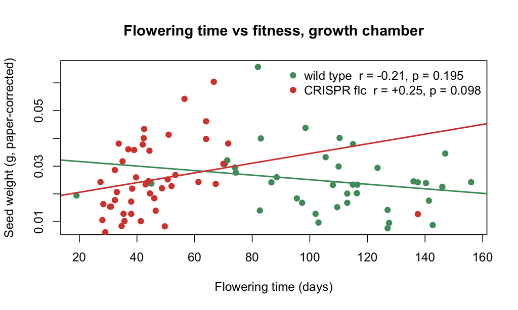

```r
plot(WTg$ft, WTg$fit, pch = 19, col = "#4E9A6A",
     xlab = "Flowering time (days)", ylab = "Seed weight (g, paper-corrected)",
     main = "Flowering time vs fitness, growth chamber")
points(MUTg$ft, MUTg$fit, pch = 19, col = "#D7473A")
abline(lm(fit ~ ft, data = WTg),  col = "#4E9A6A", lwd = 2)
abline(lm(fit ~ ft, data = MUTg), col = "#D7473A", lwd = 2)
legend("topright", bty = "n", pch = 19, col = c("#4E9A6A", "#D7473A"),
       legend = c("wild type  r = -0.21, p = 0.195", "CRISPR flc  r = +0.25, p = 0.098"))
```

Neither correlation is individually significant, but they differ from each other (interaction p = 0.033; Fisher z = 2.08, p = 0.037 at full precision — the published “z = 2.07, p = 0.038” is the same test computed from the rounded correlations −0.21 and 0.25): the relationship reverses sign rather than disappearing. Over the same lines, fitness vs δ¹³C is r = −0.19 (p = 0.24) in wild types and r = 0.40 (p = 0.004) in edited lines — so WUE carries the stronger and only individually significant fitness association in the edited background.

**Caveat.** Flowering time in this chamber experiment spans 27.3–137.5 d in the edited lines, unlike 13.9–35.8 d in Uli’s δ¹³C panel. The two experiments are not the same set of lines, so the 32-fold variance collapse reported above applies to Uli’s panel only.

# Supplement §VIII.2 — every number, in order

One chunk per claim, in the order the supplement makes them, so this section can be checked line-by-line against the text. Expected values from the current supplement are noted inline; everything reuses objects loaded above.

## δ¹³C rank consistency between wild types and their flc counterparts

Expected: Spearman ρ = 0.66, p = 0.002; Pearson r = 0.77, p = 1×10⁻⁴, over the 19 wt–flc pairs.

```r
Ep <- subset(d, label == "mut"); Wp <- subset(d, label == "wt")
Ep$acc <- firstnum(Ep$line); Wp$acc <- firstnum(Wp$line)
pw <- merge(Wp[, c("acc", "deltaC_mean_mean")], Ep[, c("acc", "deltaC_mean_mean")],
            by = "acc", suffixes = c("_wt", "_mut"))
c(n_pairs = nrow(pw))
```

```
## n_pairs
##      19
```

```r
suppressWarnings(   # ties -> approximate Spearman p
  cor.test(pw$deltaC_mean_mean_wt, pw$deltaC_mean_mean_mut, method = "spearman"))
```

```
##
##  Spearman's rank correlation rho
##
## data:  pw$deltaC_mean_mean_wt and pw$deltaC_mean_mean_mut
## S = 385.67, p-value = 0.002031
## alternative hypothesis: true rho is not equal to 0
## sample estimates:
##       rho
## 0.6616938
```

```r
cor.test(pw$deltaC_mean_mean_wt, pw$deltaC_mean_mean_mut)
```

```
##
##  Pearson's product-moment correlation
##
## data:  pw$deltaC_mean_mean_wt and pw$deltaC_mean_mean_mut
## t = 5.0221, df = 17, p-value = 0.0001046
## alternative hypothesis: true correlation is not equal to 0
## 95 percent confidence interval:
##  0.4910726 0.9082531
## sample estimates:
##       cor
## 0.7728892
```

## Measured phenotypes: r, slope, covariance, SD, CV per set

Expected: 19 paired edited r = 0.50, p = 0.030; 29 edited r = 0.38, p = 0.045, slope 4.58 ± 2.18, cov 0.90, SD 0.44 ‰ / 5.4 d, CV 1.44 % / 24.5 %; 20 progenitors + Col-0 r = 0.14, p = 0.55, slope 10.44 ± 16.94, cov 1.88, SD 0.42 / 30.8, CV 1.40 / 43.6; 248 natural (FT16) r = 0.38, p = 5.2×10⁻¹⁰, slope 8.63 ± 1.33, cov 12.26, SD 1.19 / 27.0, CV 3.35 / 31.5. (FT10 gives the same qualitative picture — Core statistics table above.)

```r
statcv <- function(x, y, lab) {
  ok <- !is.na(x) & !is.na(y); x <- x[ok]; y <- y[ok]
  cbind(stat(x, y, lab),
        CV_d13C_pct = round(relsd(x), 2), CV_FT_pct = round(cvpct(y), 2)) }

knitr::kable(rbind(
  statcv(pr$deltaC_mean_mean, pr$dag_mean,   "19 edited (paired)"),
  statcv(E$deltaC_mean_mean,  E$dag_mean,    "29 edited"),
  statcv(WC$deltaC_mean_mean, WC$dag_mean,   "20 progenitors + Col-0"),
  statcv(at16$Delta_13C,      at16$FT16,     "248 natural (FT16)")), row.names = FALSE)
```

| set | n | r | p | slope | slope_SE | cov | sd_d13C | sd_FT | CV_d13C_pct | CV_FT_pct |
| --- | --- | --- | --- | --- | --- | --- | --- | --- | --- | --- |
| 19 edited (paired) | 19 | 0.499 | 0.0298 | 6.15 | 2.59 | 1.331 | 0.465 | 5.74 | 1.51 | 24.91 |
| 29 edited | 29 | 0.376 | 0.0447 | 4.58 | 2.18 | 0.902 | 0.444 | 5.41 | 1.44 | 24.49 |
| 20 progenitors + Col-0 | 20 | 0.144 | 0.5450 | 10.44 | 16.94 | 1.876 | 0.424 | 30.79 | 1.40 | 43.59 |
| 248 natural (FT16) | 248 | 0.381 | 0.0000 | 8.63 | 1.33 | 12.262 | 1.192 | 26.97 | 3.35 | 31.50 |

The Col-0 scale anchor (expected: −31.14 ‰ measured here vs −37.21 ‰ reference used with the published dataset — ranks comparable across experiments, absolute values not):

```r
c(col0_measured_here = d$deltaC_mean_mean[d$label == "col"], col0_published_ref = -37.21)
```

```
## col0_measured_here col0_published_ref
##             -31.14             -37.21
```

## Fisher z on the measured correlations

Expected: 29 edited vs 20 progenitors + Col-0 z = 0.802, p = 0.423; 29 edited vs 248 natural z = −0.033, p = 0.974.

```r
rbind(
  `29 edited vs 20 progenitors+Col-0` = fz(cor(E$deltaC_mean_mean, E$dag_mean),
      cor(WC$deltaC_mean_mean, WC$dag_mean), nrow(E), nrow(WC)),
  `29 edited vs 248 natural (FT16)`   = fz(cor(E$deltaC_mean_mean, E$dag_mean),
      cor(at16$Delta_13C, at16$FT16), nrow(E), nrow(at16)))
```

```
##                                        z      p
## 29 edited vs 20 progenitors+Col-0  0.802 0.4227
## 29 edited vs 248 natural (FT16)   -0.033 0.9736
```

## Variance F tests, measured

Expected: δ¹³C progenitors-vs-edited F = 0.91, p = 0.85; flowering time F = 32.35, p = 6.4×10⁻¹⁴; vs the 248 natural accessions δ¹³C F = 7.22, p = 6.8×10⁻⁸ and flowering time F = 24.82, p = 8.4×10⁻¹⁵. The relative-variation claims (δ¹³C CV 1.44 % vs 1.40 %, flowering-time CV 1.8-fold lower) are the CV columns above and the ratio pair in the Relative variation section.

```r
vt <- function(x, y, lab) { v <- var.test(x, y)
  data.frame(comparison = lab, F = round(unname(v$statistic), 2),
             df = paste(v$parameter, collapse = ", "), p = signif(v$p.value, 2)) }
knitr::kable(rbind(
  vt(WC$deltaC_mean_mean, E$deltaC_mean_mean, "d13C: 20 progenitors+Col-0 vs 29 edited"),
  vt(WC$dag_mean,         E$dag_mean,         "FT:   20 progenitors+Col-0 vs 29 edited"),
  vt(at16$Delta_13C,      E$deltaC_mean_mean, "d13C: 248 natural vs 29 edited"),
  vt(at16$FT16,           E$dag_mean,         "FT:   248 natural vs 29 edited")),
  row.names = FALSE)
```

| comparison | F | df | p |
| --- | --- | --- | --- |
| d13C: 20 progenitors+Col-0 vs 29 edited | 0.91 | 19, 28 | 8.5e-01 |
| FT: 20 progenitors+Col-0 vs 29 edited | 32.35 | 19, 28 | 0.0e+00 |
| d13C: 248 natural vs 29 edited | 7.22 | 247, 28 | 1.0e-07 |
| FT: 248 natural vs 29 edited | 24.82 | 247, 28 | 0.0e+00 |

## Imputed phenotypes: the three quoted blocks

Expected: 28 edited (CS77069 absent from the imputed panel) r = 0.38, p = 0.049, slope 4.58 ± 2.22, cov 0.94, SD 0.45 / 5.5, CV 1.47 / 25.0; 19 progenitors (Col-0 absent) r = 0.14, p = 0.57, slope 2.56 ± 4.46, cov 6.29, SD 1.57 / 29.1, CV 4.43 / 39.7; 1135 natural accessions, imputed δ¹³C × imputed FT16, r = 0.59, p = 8.0×10⁻¹⁰⁶, slope 19.90 ± 0.82, cov 10.47, SD 0.73 / 24.6, CV 2.02 / 32.5.

```r
# E28, W19, ai are built in the Core statistics chunk
c(absent_edited = subset(m, label == "mut" & is.na(flc_mut_dc13))$line,
  absent_wt     = subset(m, label %in% c("wt", "col") & is.na(wt_dc13))$line)
```

```
##      absent_edited          absent_wt
## "IDCS77069-05-R03"              "COL"
```

```r
knitr::kable(rbind(
  statcv(E28$flc_mut_dc13, E28$dag_mean, "28 edited, imputed d13C"),
  statcv(W19$wt_dc13,      W19$dag_mean, "19 progenitors, imputed d13C"),
  statcv(ai$Delta_13C,     ai$FT16,      "1135 natural, imputed (FT16)")),
  row.names = FALSE)
```

| set | n | r | p | slope | slope_SE | cov | sd_d13C | sd_FT | CV_d13C_pct | CV_FT_pct |
| --- | --- | --- | --- | --- | --- | --- | --- | --- | --- | --- |
| 28 edited, imputed d13C | 28 | 0.376 | 0.0489 | 4.58 | 2.22 | 0.935 | 0.452 | 5.51 | 1.47 | 24.95 |
| 19 progenitors, imputed d13C | 19 | 0.138 | 0.5740 | 2.56 | 4.46 | 6.288 | 1.568 | 29.09 | 4.43 | 39.67 |
| 1135 natural, imputed (FT16) | 1135 | 0.586 | 0.0000 | 19.90 | 0.82 | 10.466 | 0.725 | 24.61 | 2.02 | 32.48 |

## Fisher z and F test on the imputed sets

Expected: 28 edited vs 19 progenitors z = 0.800, p = 0.424; 28 edited vs 1135 natural z = −1.372, p = 0.170; flowering-time variance F = 27.85, p = 1.3×10⁻¹².

```r
rbind(
  `28 edited vs 19 progenitors (imputed)` = fz(cor(E28$flc_mut_dc13, E28$dag_mean),
      cor(W19$wt_dc13, W19$dag_mean), nrow(E28), nrow(W19)),
  `28 edited vs 1135 natural (imputed)`   = fz(cor(E28$flc_mut_dc13, E28$dag_mean),
      cor(ai$Delta_13C, ai$FT16), nrow(E28), nrow(ai)))
```

```
##                                            z      p
## 28 edited vs 19 progenitors (imputed)  0.800 0.4238
## 28 edited vs 1135 natural (imputed)   -1.372 0.1700
```

```r
var.test(W19$dag_mean, E28$dag_mean)
```

```
##
##  F test to compare two variances
##
## data:  W19$dag_mean and E28$dag_mean
## F = 27.85, num df = 18, denom df = 27, p-value = 1.272e-12
## alternative hypothesis: true ratio of variances is not equal to 1
## 95 percent confidence interval:
##  12.15526 68.80626
## sample estimates:
## ratio of variances
##           27.84985
```

## Traits vs fitness (seed weight, growth chamber)

Expected: flowering time vs seed weight r = −0.21, p = 0.195, n = 39 in wild types and r = 0.25, p = 0.098, n = 46 in edited lines; genotype × flowering-time interaction p = 0.033; Fisher z = 2.07, p = 0.038 (full precision gives 2.08 / 0.037 — the quoted 2.07 is z computed from the rounded correlations). The interaction model is in the previous section (`ftfit_tests`); `cor.test` drops the two wild-type lines with no flowering-time record, giving n = 39 of the 41.

```r
unlist(lapply(list(wt = cor.test(WTg$ft, WTg$fit), flc = cor.test(MUTg$ft, MUTg$fit)),
  function(ct) c(n = unname(ct$parameter) + 2, r = round(unname(ct$estimate), 2),
                 p = round(ct$p.value, 3))))
```

```
##   wt.n   wt.r   wt.p  flc.n  flc.r  flc.p
## 39.000 -0.210  0.195 46.000  0.250  0.098
```

```r
fz(cor(MUTg$ft, MUTg$fit, use = "complete"), cor(WTg$ft, WTg$fit, use = "complete"),
   nrow(MUTg), sum(complete.cases(WTg$ft, WTg$fit)))
```

```
##      z      p
## 2.0810 0.0374
```

Expected: fitness vs δ¹³C r = 0.40, p = 0.004 in the edited lines and r = −0.19, p = 0.24 in the wild types. The two halves use different δ¹³C sources: the edited lines use chamber-measured `mean_dC13_ko` (the Fig. 3C flc source), while the wild-type value reproduces exactly from **imputed** `wt_dc13` over the 41 growth-chamber wild-type lines — which identifies the wild-type half of the published Fig. 3C statistic, listed as missing in `figures-main/Fig3C-remake/README.md` (the plotted wild-type points remain PDF-recovered; only the correlation is confirmed here).

```r
fd  <- read.csv(file.path(DAT, "flc_droughtexp_data.csv"))
ik  <- read.csv(file.path(DAT, "imputed_mutant_dC13.csv"))
fmm <- merge(fd, ik[, c("id", "mean_dC13_ko")], by = "id")
cor.test(fmm$mean_dC13_ko, fmm$rSeedWeight)      # edited: expect r = 0.405, p = 0.0047
```

```
##
##  Pearson's product-moment correlation
##
## data:  fmm$mean_dC13_ko and fmm$rSeedWeight
## t = 2.9719, df = 45, p-value = 0.004739
## alternative hypothesis: true correlation is not equal to 0
## 95 percent confidence interval:
##  0.1333995 0.6200896
## sample estimates:
##       cor
## 0.4050497
```

```r
WTg$acc <- firstnum(as.character(WTg$id))
wwt <- merge(WTg, im, by.x = "acc", by.y = "id")
cor.test(wwt$wt_dc13, wwt$fit)                   # wild type: expect r = -0.19, p = 0.235
```

```
##
##  Pearson's product-moment correlation
##
## data:  wwt$wt_dc13 and wwt$fit
## t = -1.2071, df = 39, p-value = 0.2347
## alternative hypothesis: true correlation is not equal to 0
## 95 percent confidence interval:
##  -0.4699826  0.1251881
## sample estimates:
##        cor
## -0.1897713
```

## Checklist

| §VIII.2 claim | chunk | reproduces? |
| --- | --- | --- |
| ρ = 0.66 / r = 0.77 wt–flc rank consistency | `viii2_pairs` | yes (0.662 / 0.773) |
| measured r, slope, cov, SD, CV — 3 sets + paired 19 | `viii2_measured` | yes |
| Col-0 −31.14 vs −37.21 reference | `viii2_col0` | yes |
| Fisher z 0.802 / −0.033 (measured) | `viii2_fisherz` | yes |
| F tests 0.91, 32.35, 7.22, 24.82 | `viii2_ftests` | yes |
| CV 1.44 vs 1.40 %; FT CV 1.8× lower | `viii2_measured` + Relative variation | yes |
| imputed blocks n = 28 / 19 / 1135 | `viii2_imputed` | yes |
| Fisher z 0.800 / −1.372; F = 27.85 (imputed) | `viii2_imputed_tests` | yes |
| FT–fitness r = −0.21 / 0.25; interaction; z = 2.07 | `viii2_fitness_ft` + `ftfit_tests` | yes (2.08 full precision) |
| δ¹³C–fitness r = −0.19 / 0.40 | `viii2_fitness_wue` | yes |

# Summary

[output not shown]

The constraint is relaxed because flowering-time variance collapses, not because the genetic correlation between the traits changes.